# EDA_ALSPAC

2025-06-09

```r
library(foreign)
library(tidyverse)
```

Reading in ALSPAC data

```r
alspac = read.spss("Ulven_B3777_13Jan22.sav",to.data.frame = TRUE,add.undeclared.levels = "no")
```

```
## re-encoding from CP1252
```

```r
#str(alspac)
```

Checking data structure

```r
str(alspac)
```

```
## 'data.frame':    15646 obs. of  58 variables:
##  $ cidB3777          : num  1 2 3 4 6 7 8 10 12 13 ...
##  $ qlet              : chr  "A" "A" "A" "A" ...
##  $ areases_quint_preg: num  NA NA 1 3 1 5 5 5 5 3 ...
##  $ no2_preg          : num  NA NA 22 26.9 29.6 26.5 27.9 27.4 33.3 27.9 ...
##  $ pm25_preg         : num  NA NA 14.5 13.5 13.3 13.4 13.4 13 14.5 13.8 ...
##  $ pm10_preg         : num  NA NA 27.8 29.8 NA ...
##  $ kz011b            : Factor w/ 4 levels "Consent withdrawn",..: 3 3 3 3 3 3 3 3 3 3 ...
##  $ kz021             : Factor w/ 4 levels "Consent withdrawn",..: 4 4 4 3 3 3 4 4 4 4 ...
##  $ kz030             : num  NA NA 3520 3570 3700 3340 2740 2900 3970 3600 ...
##   ..- attr(*, "value.labels")= Named chr [1:3] "-10" "-11" "-9999"
##   .. ..- attr(*, "names")= chr [1:3] "Not in core sample" "Triplet / quadruplet" "Consent withdrawn"
##  $ chol_cord         : num  NA NA NA 0.77 NA 1.46 NA 1.85 2.06 NA ...
##   ..- attr(*, "value.labels")= Named chr [1:3] "-1" "-11" "-9999"
##   .. ..- attr(*, "names")= chr [1:3] "Missing/Not assayed" "Trip/Quad" "Consent withdrawn"
##  $ trig_cord         : num  NA NA NA 0.41 NA 0.34 NA 0.7 0.63 NA ...
##   ..- attr(*, "value.labels")= Named chr [1:4] "-1" "-2" "-11" "-9999"
##   .. ..- attr(*, "names")= chr [1:4] "Missing/Not assayed" "Out of detectable range (<0.1 or >10 mmol/L)" "Trip/Quad" "Consent withdrawn"
##  $ HDL_cord          : num  NA NA NA 0.23 NA 0.35 NA 0.38 0.74 NA ...
##   ..- attr(*, "value.labels")= Named chr [1:5] "-1" "-2" "-8" "-11" ...
##   .. ..- attr(*, "names")= chr [1:5] "Missing/Not assayed" "Out of detectable range (<0.08 or >3.12 mmol/L)" "Unresolvable" "Trip/Quad" ...
##  $ LDL_cord          : num  NA NA NA 0.354 NA ...
##   ..- attr(*, "value.labels")= Named chr [1:4] "-1" "-8" "-11" "-9999"
##   .. ..- attr(*, "names")= chr [1:4] "Missing/Not assayed" "Unresolvable" "Trip/Quad" "Consent withdrawn"
##  $ CRP_cord          : num  NA NA NA 0.06 NA 0 NA 0 0 NA ...
##   ..- attr(*, "value.labels")= Named chr [1:4] "-1" "-8" "-11" "-9999"
##   .. ..- attr(*, "names")= chr [1:4] "Missing/Not assayed" "Unresolvable" "Trip/Quad" "Consent withdrawn"
##  $ Trig_CIF31        : num  NA NA NA NA NA NA NA NA NA NA ...
##   ..- attr(*, "value.labels")= Named chr [1:3] "-1" "-11" "-9999"
##   .. ..- attr(*, "names")= chr [1:3] "Missing/Not assayed" "Trip/Quad" "Consent withdrawn"
##  $ Chol_CIF31        : num  NA NA NA NA NA NA NA NA NA NA ...
##   ..- attr(*, "value.labels")= Named chr [1:3] "-1" "-11" "-9999"
##   .. ..- attr(*, "names")= chr [1:3] "Missing/Not assayed" "Trip/Quad" "Consent withdrawn"
##  $ LDL_CIF31         : num  NA NA NA NA NA NA NA NA NA NA ...
##   ..- attr(*, "value.labels")= Named chr [1:3] "-1" "-11" "-9999"
##   .. ..- attr(*, "names")= chr [1:3] "Missing/Not assayed" "Trip/Quad" "Consent withdrawn"
##  $ HDL_CIF31         : num  NA NA NA NA NA NA NA NA NA NA ...
##   ..- attr(*, "value.labels")= Named chr [1:3] "-1" "-11" "-9999"
##   .. ..- attr(*, "names")= chr [1:3] "Missing/Not assayed" "Trip/Quad" "Consent withdrawn"
##  $ Trig_CIF43        : num  NA NA NA NA NA NA NA NA NA NA ...
```

[output cut: 83 more lines]

```
##  $ b862              : num  NA NA 10.9 NA 1.9 ...
##   ..- attr(*, "value.labels")= Named chr [1:2] "-1" "-9999"
##   .. ..- attr(*, "names")= chr [1:2] "Missing" "Consent withdrawn"
##  $ c645a             : Factor w/ 8 levels "Consent withdrawn",..: NA NA 7 4 4 4 6 5 4 8 ...
##  $ c755              : Factor w/ 9 levels "Consent withdrawn",..: NA NA 4 5 4 NA NA 5 7 5 ...
##  $ c765              : Factor w/ 9 levels "Consent withdrawn",..: NA NA 3 4 6 NA NA 6 6 3 ...
##  $ c800              : Factor w/ 12 levels "Consent withdrawn",..: NA NA NA 3 3 3 3 3 3 3 ...
##  $ c804              : Factor w/ 4 levels "Consent withdrawn",..: NA NA NA 3 3 3 3 3 3 3 ...
##  $ dw042             : num  NA NA 19.3 NA 21.3 ...
##   ..- attr(*, "value.labels")= Named chr [1:2] "-3" "-9999"
##   .. ..- attr(*, "names")= chr [1:2] "Missing" "Consent withdrawn"
##  $ bestgest          : num  NA NA 39 40 38 36 38 41 41 41 ...
##  - attr(*, "variable.labels")= Named chr [1:58] "Unique pregnancy identifier for Stine Marie Ulven(ACGHEBFD)" "Birth order letter A = singleton; B = twin; C = triplet; D = quad" "Area SES quintiles at pregnancy" "NO2 (ug/m3) at pregnancy" ...
##   ..- attr(*, "names")= chr [1:58] "cidB3777" "qlet" "areases_quint_preg" "no2_preg" ...
##  - attr(*, "codepage")= int 1252
```

```r
alspac = alspac %>%
  mutate(across(c("chol_cord","trig_cord","HDL_cord","LDL_cord","CRP_cord",
                  "Trig_CIF31","Chol_CIF31","LDL_CIF31","HDL_CIF31",
                  "Trig_CIF43","Chol_CIF43","LDL_CIF43","HDL_CIF43",
                  "Chol_BBS","Trig_BBS","LDL_BBS","CHOL_F7","TRIG_F7","HDL_F7",
                  "LDL_F7","CHOL_F9","trig_f9","HDL_f9","LDL_f9","VLDL_f9","CRP_f9","IL6_f9"),as.numeric))
str(alspac)
```

```
## 'data.frame':    15646 obs. of  58 variables:
##  $ cidB3777          : num  1 2 3 4 6 7 8 10 12 13 ...
##  $ qlet              : chr  "A" "A" "A" "A" ...
##  $ areases_quint_preg: num  NA NA 1 3 1 5 5 5 5 3 ...
##  $ no2_preg          : num  NA NA 22 26.9 29.6 26.5 27.9 27.4 33.3 27.9 ...
##  $ pm25_preg         : num  NA NA 14.5 13.5 13.3 13.4 13.4 13 14.5 13.8 ...
##  $ pm10_preg         : num  NA NA 27.8 29.8 NA ...
##  $ kz011b            : Factor w/ 4 levels "Consent withdrawn",..: 3 3 3 3 3 3 3 3 3 3 ...
##  $ kz021             : Factor w/ 4 levels "Consent withdrawn",..: 4 4 4 3 3 3 4 4 4 4 ...
##  $ kz030             : num  NA NA 3520 3570 3700 3340 2740 2900 3970 3600 ...
##   ..- attr(*, "value.labels")= Named chr [1:3] "-10" "-11" "-9999"
##   .. ..- attr(*, "names")= chr [1:3] "Not in core sample" "Triplet / quadruplet" "Consent withdrawn"
##  $ chol_cord         : num  NA NA NA 0.77 NA 1.46 NA 1.85 2.06 NA ...
##  $ trig_cord         : num  NA NA NA 0.41 NA 0.34 NA 0.7 0.63 NA ...
##  $ HDL_cord          : num  NA NA NA 0.23 NA 0.35 NA 0.38 0.74 NA ...
##  $ LDL_cord          : num  NA NA NA 0.354 NA ...
##  $ CRP_cord          : num  NA NA NA 0.06 NA 0 NA 0 0 NA ...
##  $ Trig_CIF31        : num  NA NA NA NA NA NA NA NA NA NA ...
##  $ Chol_CIF31        : num  NA NA NA NA NA NA NA NA NA NA ...
##  $ LDL_CIF31         : num  NA NA NA NA NA NA NA NA NA NA ...
##  $ HDL_CIF31         : num  NA NA NA NA NA NA NA NA NA NA ...
##  $ Trig_CIF43        : num  NA NA NA NA NA NA NA NA NA NA ...
##  $ Chol_CIF43        : num  NA NA NA NA NA NA NA NA NA NA ...
##  $ LDL_CIF43         : num  NA NA NA NA NA NA NA NA NA NA ...
##  $ HDL_CIF43         : num  NA NA NA NA NA NA NA NA NA NA ...
##  $ Chol_BBS          : num  NA NA NA NA NA NA NA NA NA NA ...
##  $ Trig_BBS          : num  NA NA NA NA NA NA NA NA NA NA ...
##  $ HDL_BBS           : num  NA NA NA NA NA NA NA NA NA NA ...
##   ..- attr(*, "value.labels")= Named chr [1:3] "-1" "-11" "-9999"
##   .. ..- attr(*, "names")= chr [1:3] "Missing/Not assayed" "Trip/Quad" "Consent withdrawn"
##  $ LDL_BBS           : num  NA NA NA NA NA NA NA NA NA NA ...
##  $ CHOL_F7           : num  5.75 NA NA NA NA NA NA NA NA 4.37 ...
##  $ TRIG_F7           : num  1.83 NA NA NA NA NA NA NA NA 1.37 ...
##  $ HDL_F7            : num  1.26 NA NA NA NA NA NA NA NA 1.69 ...
##  $ LDL_F7            : num  3.61 NA NA NA NA NA NA NA NA 2.06 ...
##  $ CHOL_F9           : num  5.42 NA 4.09 NA 3.83 NA NA NA NA 3.98 ...
##  $ trig_f9           : num  0.74 NA 1.61 NA 0.37 NA NA NA NA 0.91 ...
##  $ HDL_f9            : num  1.47 NA 1.21 NA 1.67 NA NA NA NA 1.61 ...
##  $ LDL_f9            : num  3.61 NA 2.14 NA 1.99 ...
##  $ VLDL_f9           : num  0.338 NA 0.735 NA 0.169 ...
```

[output cut: 29 more lines]

```
##  $ b862              : num  NA NA 10.9 NA 1.9 ...
##   ..- attr(*, "value.labels")= Named chr [1:2] "-1" "-9999"
##   .. ..- attr(*, "names")= chr [1:2] "Missing" "Consent withdrawn"
##  $ c645a             : Factor w/ 8 levels "Consent withdrawn",..: NA NA 7 4 4 4 6 5 4 8 ...
##  $ c755              : Factor w/ 9 levels "Consent withdrawn",..: NA NA 4 5 4 NA NA 5 7 5 ...
##  $ c765              : Factor w/ 9 levels "Consent withdrawn",..: NA NA 3 4 6 NA NA 6 6 3 ...
##  $ c800              : Factor w/ 12 levels "Consent withdrawn",..: NA NA NA 3 3 3 3 3 3 3 ...
##  $ c804              : Factor w/ 4 levels "Consent withdrawn",..: NA NA NA 3 3 3 3 3 3 3 ...
##  $ dw042             : num  NA NA 19.3 NA 21.3 ...
##   ..- attr(*, "value.labels")= Named chr [1:2] "-3" "-9999"
##   .. ..- attr(*, "names")= chr [1:2] "Missing" "Consent withdrawn"
##  $ bestgest          : num  NA NA 39 40 38 36 38 41 41 41 ...
##  - attr(*, "variable.labels")= Named chr [1:58] "Unique pregnancy identifier for Stine Marie Ulven(ACGHEBFD)" "Birth order letter A = singleton; B = twin; C = triplet; D = quad" "Area SES quintiles at pregnancy" "NO2 (ug/m3) at pregnancy" ...
##   ..- attr(*, "names")= chr [1:58] "cidB3777" "qlet" "areases_quint_preg" "no2_preg" ...
##  - attr(*, "codepage")= int 1252
```

Drop extra factors from variables that are categorical

Count the NA values per sample

```r
na_count = apply(alspac,2,function(x){sum(is.na(x))})
na_count_o = sort(na_count,decreasing = TRUE)
na_count_o[1:10]
```

```
##  HDL_CIF31  LDL_CIF31 Trig_CIF31 Chol_CIF31  HDL_CIF43 Trig_CIF43 Chol_CIF43
##      15278      15274      15150      15150      15037      15033      15033
##  LDL_CIF43   Chol_BBS   Trig_BBS
##      15033      14778      14778
```

```r
varibles_half_na = names(na_count_o)[na_count_o >= max(na_count_o)/2]
`%ni%` = Negate(`%in%`)
alspac_use = alspac[,colnames(alspac) %ni% varibles_half_na]
```

Using mice for missing data analysis among remaining variables

```r
library(mice)
library(VIM)
```

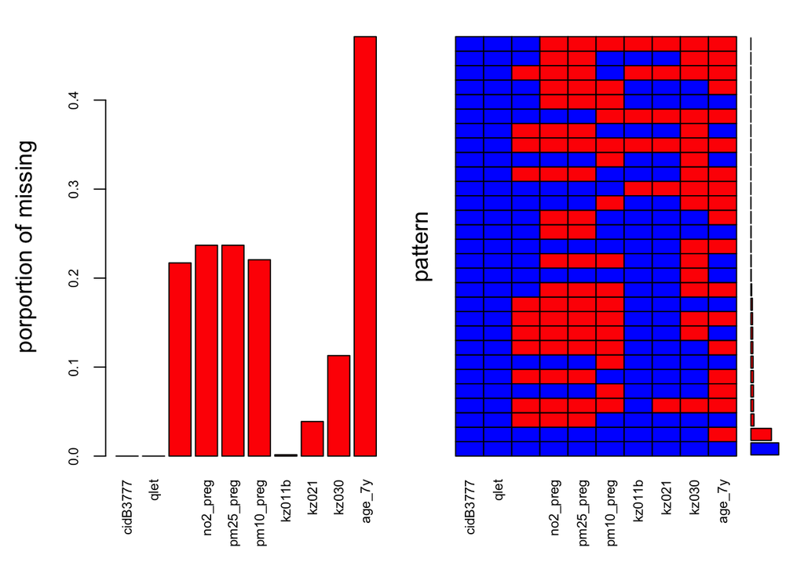

```r
## red is missing and blue is not missing
missing_val_plot = aggr(alspac_use[,c(1:10)], col=c("blue","red"),
                   numbers=TRUE,sortVard=TRUE,
                     labels = names(alspac_use),cex.axis=.7,
                       gap=3,ylab=c("porportion of missing","pattern"))
```

```r
#md.pattern(alspac_use,rotate.names = TRUE)
```

Display missing-data patterns

```r
tab.pattern=md.pattern(alspac_use[,c(1:10)],rotate.names = TRUE) ## difficul tot understand
```

[figure not shown]

[figure not shown]

[output not shown]

[output cut: 31 more lines]

```r
md.pattern(alspac_use[,c(1,11:20)],rotate.names = TRUE)
```

[figure not shown]

[output not shown]

[output cut: 20 more lines]

```r
md.pattern(alspac_use[,c(1,21:26)],rotate.names = TRUE)
```

Doing missing data pattern for the most interesting variables

```r
cols_use = c("cidB3777","no2_preg","pm25_preg","pm10_preg","kz021","c800","c804","c645a","b650")
pdf("Missing_pattern_table.pdf",width = 10,height = 10)
md.pattern(alspac_use[,cols_use],rotate.names = TRUE)
```

```
##      cidB3777 kz021 b650 c645a c800 pm10_preg c804 no2_preg pm25_preg
## 9168        1     1    1     1    1         1    1        1         1     0
## 1037        1     1    1     1    1         1    1        0         0     2
## 168         1     1    1     1    1         1    0        1         1     1
## 25          1     1    1     1    1         1    0        0         0     3
## 861         1     1    1     1    1         0    1        1         1     1
## 644         1     1    1     1    1         0    1        0         0     3
## 28          1     1    1     1    1         0    0        1         1     2
## 12          1     1    1     1    1         0    0        0         0     4
## 1           1     1    1     1    0         1    1        1         1     1
## 108         1     1    1     1    0         1    0        1         1     2
## 12          1     1    1     1    0         1    0        0         0     4
## 11          1     1    1     1    0         0    0        1         1     3
## 11          1     1    1     1    0         0    0        0         0     5
## 43          1     1    1     0    1         1    1        1         1     1
```

[output cut: 35 more lines]

```r
dev.off()
```

Both no2_preg and pm25_preg have the most missing values

```r
missing_b650<-is.na(alspac_use$b650)#Missing indicator for ever smoked

missing_c645a<-is.na(alspac_use$c645a)#Missing indicator for mom education

missing_c800<-is.na(alspac_use$c800)#Missing indicator for ethnic group

missing_c804<-is.na(alspac_use$c804)#Missing indicator for child ethnicity

missing_areases<-is.na(alspac_use$areases_quint_preg)#Missing indicator for areaSES
```

```r
tapply(X=alspac_use$pm25_preg,INDEX=missing_b650,FUN=mean,na.rm=T)
```

```
##    FALSE     TRUE
## 13.33947 13.35979
```

```r
tapply(X=alspac_use$pm25_preg,INDEX=missing_c645a,FUN=mean,na.rm=T)
```

```
##    FALSE     TRUE
## 13.33805 13.36315
```

```r
tapply(X=alspac_use$pm25_preg,INDEX=missing_c800,FUN=mean,na.rm=T)
```

```
##    FALSE     TRUE
## 13.33840 13.35898
```

```r
tapply(X=alspac_use$pm25_preg,INDEX=missing_c804,FUN=mean,na.rm=T)
```

```
##    FALSE     TRUE
## 13.33690 13.36614
```

```r
tapply(X=alspac_use$pm25_preg,INDEX=missing_areases,FUN=mean,na.rm=T)
```

```
##    FALSE     TRUE
## 13.34077      NaN
```

Above table suggests no notable difference pm25_preg for those categorical variables.

```r
t.test(alspac_use$pm25_preg ~ missing_b650)
```

```
##
##  Welch Two Sample t-test
##
## data:  alspac_use$pm25_preg by missing_b650
## t = -0.69963, df = 897.66, p-value = 0.4843
## alternative hypothesis: true difference in means between group FALSE and group TRUE is not equal to 0
## 95 percent confidence interval:
##  -0.07732555  0.03668361
## sample estimates:
## mean in group FALSE  mean in group TRUE
##            13.33947            13.35979
```

```r
t.test(alspac_use$pm25_preg ~ missing_c645a)
```

```
##
##  Welch Two Sample t-test
##
## data:  alspac_use$pm25_preg by missing_c645a
## t = -1.0315, df = 1650.2, p-value = 0.3025
## alternative hypothesis: true difference in means between group FALSE and group TRUE is not equal to 0
## 95 percent confidence interval:
##  -0.07282337  0.02262665
## sample estimates:
## mean in group FALSE  mean in group TRUE
##            13.33805            13.36315
```

```r
t.test(alspac_use$pm25_preg ~ missing_c800)
```

```
##
##  Welch Two Sample t-test
##
## data:  alspac_use$pm25_preg by missing_c800
## t = -0.86792, df = 1777, p-value = 0.3856
## alternative hypothesis: true difference in means between group FALSE and group TRUE is not equal to 0
## 95 percent confidence interval:
##  -0.06707896  0.02592335
## sample estimates:
## mean in group FALSE  mean in group TRUE
##            13.33840            13.35898
```

```r
t.test(alspac_use$pm25_preg ~ missing_c804)
```

```
##
##  Welch Two Sample t-test
##
## data:  alspac_use$pm25_preg by missing_c804
## t = -1.3094, df = 2131.1, p-value = 0.1905
## alternative hypothesis: true difference in means between group FALSE and group TRUE is not equal to 0
## 95 percent confidence interval:
##  -0.07304217  0.01455466
## sample estimates:
## mean in group FALSE  mean in group TRUE
##            13.33690            13.36614
```

```r
#t.test(alspac_use$pm25_preg ~ missing_areases)
```

There is no significant difference in PM2.5 exposure for those with or without data on some potential covariates. Making a jitter plot for PM2.5 by various groups

[figure not shown]

```r
plot(jitter(as.numeric(missing_c804)),alspac_use$pm25_preg,ylim=c(9,16),
            xaxt="n",
            xlab="Mother ever smoked missingness",
            ylab="PM2.5 during pregnancy")
axis(1, at=c(0,1), labels=c("Not missing","Missing"))

abline(h=quantile(alspac_use$pm25_preg,1/4,na.rm=T)-1.5*IQR(alspac_use$pm25_preg,na.rm=T),col="red")
```

```r
tapply(X=alspac_use$pm10_preg,INDEX=missing_b650,FUN=mean,na.rm=T)
```

```
##    FALSE     TRUE
## 31.14124 31.47441
```

```r
tapply(X=alspac_use$pm10_preg,INDEX=missing_c645a,FUN=mean,na.rm=T)
```

```
##    FALSE     TRUE
## 31.13799 31.36386
```

```r
tapply(X=alspac_use$pm10_preg,INDEX=missing_c800,FUN=mean,na.rm=T)
```

```
##    FALSE     TRUE
## 31.13199 31.39760
```

```r
tapply(X=alspac_use$pm10_preg,INDEX=missing_c804,FUN=mean,na.rm=T)
```

```
##    FALSE     TRUE
## 31.13187 31.36441
```

```r
tapply(X=alspac_use$pm10_preg,INDEX=missing_areases,FUN=mean,na.rm=T)
```

```
##    FALSE     TRUE
## 31.16037 31.18655
```

T test for PM10

```r
t.test(alspac_use$pm10_preg ~ missing_b650)
```

```
##
##  Welch Two Sample t-test
##
## data:  alspac_use$pm10_preg by missing_b650
## t = -4.6156, df = 922.84, p-value = 4.475e-06
## alternative hypothesis: true difference in means between group FALSE and group TRUE is not equal to 0
## 95 percent confidence interval:
##  -0.4748326 -0.1915051
## sample estimates:
## mean in group FALSE  mean in group TRUE
##            31.14124            31.47441
```

```r
t.test(alspac_use$pm10_preg ~ missing_c645a)
```

```
##
##  Welch Two Sample t-test
##
## data:  alspac_use$pm10_preg by missing_c645a
## t = -3.8678, df = 1714.7, p-value = 0.0001139
## alternative hypothesis: true difference in means between group FALSE and group TRUE is not equal to 0
## 95 percent confidence interval:
##  -0.3404006 -0.1113307
## sample estimates:
## mean in group FALSE  mean in group TRUE
##            31.13799            31.36386
```

```r
t.test(alspac_use$pm10_preg ~ missing_c800)
```

```
##
##  Welch Two Sample t-test
##
## data:  alspac_use$pm10_preg by missing_c800
## t = -4.7115, df = 1845.2, p-value = 2.643e-06
## alternative hypothesis: true difference in means between group FALSE and group TRUE is not equal to 0
## 95 percent confidence interval:
##  -0.3761749 -0.1550434
## sample estimates:
## mean in group FALSE  mean in group TRUE
##            31.13199            31.39760
```

```r
t.test(alspac_use$pm10_preg ~ missing_c804)
```

```
##
##  Welch Two Sample t-test
##
## data:  alspac_use$pm10_preg by missing_c804
## t = -4.3748, df = 2202.5, p-value = 1.272e-05
## alternative hypothesis: true difference in means between group FALSE and group TRUE is not equal to 0
## 95 percent confidence interval:
##  -0.3367764 -0.1282999
## sample estimates:
## mean in group FALSE  mean in group TRUE
##            31.13187            31.36441
```

```r
#t.test(alspac_use$pm25_preg ~ missing_areases)
```

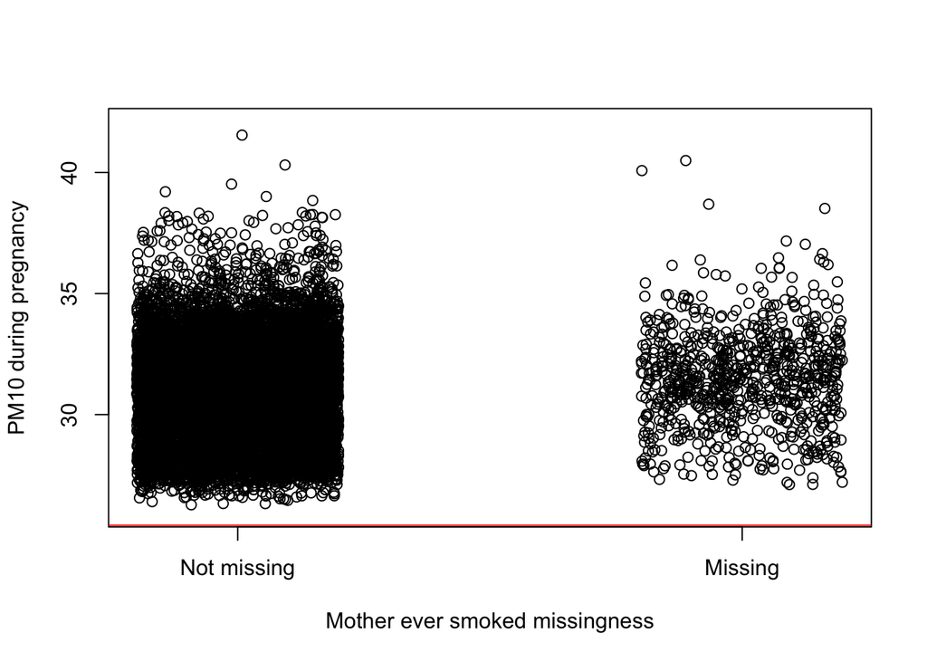

```r
plot(jitter(as.numeric(missing_b650)),alspac_use$pm10_preg,ylim=c(26,42),
            xaxt="n",
            xlab="Mother ever smoked missingness",
            ylab="PM10 during pregnancy")
axis(1, at=c(0,1), labels=c("Not missing","Missing"))

abline(h=quantile(alspac_use$pm10_preg,1/4,na.rm=T)-1.5*IQR(alspac_use$pm10_preg,na.rm=T),col="red")
```

Now, I will drop the extra levels of all categorical variables that do not have values corresponding to those levels

```r
alspac_use_no_extra_factor <- alspac_use %>%
  mutate(across(where(is.factor), fct_drop))
```

Now chekcing if extra factors dropped

```r
str(alspac_use)
```

```
## 'data.frame':    15646 obs. of  26 variables:
##  $ cidB3777          : num  1 2 3 4 6 7 8 10 12 13 ...
##  $ qlet              : chr  "A" "A" "A" "A" ...
##  $ areases_quint_preg: num  NA NA 1 3 1 5 5 5 5 3 ...
##  $ no2_preg          : num  NA NA 22 26.9 29.6 26.5 27.9 27.4 33.3 27.9 ...
##  $ pm25_preg         : num  NA NA 14.5 13.5 13.3 13.4 13.4 13 14.5 13.8 ...
##  $ pm10_preg         : num  NA NA 27.8 29.8 NA ...
##  $ kz011b            : Factor w/ 4 levels "Consent withdrawn",..: 3 3 3 3 3 3 3 3 3 3 ...
##  $ kz021             : Factor w/ 4 levels "Consent withdrawn",..: 4 4 4 3 3 3 4 4 4 4 ...
##  $ kz030             : num  NA NA 3520 3570 3700 3340 2740 2900 3970 3600 ...
##   ..- attr(*, "value.labels")= Named chr [1:3] "-10" "-11" "-9999"
##   .. ..- attr(*, "names")= chr [1:3] "Not in core sample" "Triplet / quadruplet" "Consent withdrawn"
##  $ age_7y            : num  7.65 9.15 NA NA NA ...
##   ..- attr(*, "value.labels")= Named chr "-9999"
##   .. ..- attr(*, "names")= chr "Consent withdrawn"
##  $ mz010a            : Factor w/ 4 levels "Consent withdrawn",..: 3 3 3 3 3 3 3 3 3 3 ...
##  $ mz028b            : num  NA NA 33 23 29 31 18 25 25 29 ...
##   ..- attr(*, "value.labels")= Named chr [1:8] "44" "15" "-1" "-2" ...
##   .. ..- attr(*, "names")= chr [1:8] ">43" "< 16" "Ma's DOB NK" "Miscarried" ...
##  $ a525              : Factor w/ 9 levels "Consent withdrawn",..: NA NA 7 NA 6 7 3 3 7 7 ...
##  $ b032              : num  NA NA 1 NA 1 0 0 0 0 0 ...
##   ..- attr(*, "value.labels")= Named chr [1:4] "-1" "-2" "-7" "-9999"
##   .. ..- attr(*, "names")= chr [1:4] "Missing" "Inconsistent data" "HaB short" "Consent withdrawn"
##  $ b650              : Factor w/ 5 levels "Consent withdrawn",..: NA NA 4 NA 3 3 3 3 3 3 ...
##  $ b663              : Factor w/ 8 levels "Consent withdrawn",..: NA NA 3 NA 4 4 4 3 4 3 ...
##  $ b665              : Factor w/ 8 levels "Consent withdrawn",..: NA NA 3 NA 4 4 4 3 4 3 ...
##  $ b667              : Factor w/ 8 levels "Consent withdrawn",..: NA NA 3 NA 4 4 4 3 4 3 ...
##  $ b862              : num  NA NA 10.9 NA 1.9 ...
##   ..- attr(*, "value.labels")= Named chr [1:2] "-1" "-9999"
##   .. ..- attr(*, "names")= chr [1:2] "Missing" "Consent withdrawn"
##  $ c645a             : Factor w/ 8 levels "Consent withdrawn",..: NA NA 7 4 4 4 6 5 4 8 ...
##  $ c755              : Factor w/ 9 levels "Consent withdrawn",..: NA NA 4 5 4 NA NA 5 7 5 ...
##  $ c765              : Factor w/ 9 levels "Consent withdrawn",..: NA NA 3 4 6 NA NA 6 6 3 ...
##  $ c800              : Factor w/ 12 levels "Consent withdrawn",..: NA NA NA 3 3 3 3 3 3 3 ...
##  $ c804              : Factor w/ 4 levels "Consent withdrawn",..: NA NA NA 3 3 3 3 3 3 3 ...
##  $ dw042             : num  NA NA 19.3 NA 21.3 ...
##   ..- attr(*, "value.labels")= Named chr [1:2] "-3" "-9999"
##   .. ..- attr(*, "names")= chr [1:2] "Missing" "Consent withdrawn"
##  $ bestgest          : num  NA NA 39 40 38 36 38 41 41 41 ...
```

```r
str(alspac_use_no_extra_factor)
```

```
## 'data.frame':    15646 obs. of  26 variables:
##  $ cidB3777          : num  1 2 3 4 6 7 8 10 12 13 ...
##  $ qlet              : chr  "A" "A" "A" "A" ...
##  $ areases_quint_preg: num  NA NA 1 3 1 5 5 5 5 3 ...
##  $ no2_preg          : num  NA NA 22 26.9 29.6 26.5 27.9 27.4 33.3 27.9 ...
##  $ pm25_preg         : num  NA NA 14.5 13.5 13.3 13.4 13.4 13 14.5 13.8 ...
##  $ pm10_preg         : num  NA NA 27.8 29.8 NA ...
##  $ kz011b            : Factor w/ 2 levels "Yes","No": 1 1 1 1 1 1 1 1 1 1 ...
##  $ kz021             : Factor w/ 2 levels "Male","Female": 2 2 2 1 1 1 2 2 2 2 ...
##  $ kz030             : num  NA NA 3520 3570 3700 3340 2740 2900 3970 3600 ...
##   ..- attr(*, "value.labels")= Named chr [1:3] "-10" "-11" "-9999"
##   .. ..- attr(*, "names")= chr [1:3] "Not in core sample" "Triplet / quadruplet" "Consent withdrawn"
##  $ age_7y            : num  7.65 9.15 NA NA NA ...
##   ..- attr(*, "value.labels")= Named chr "-9999"
##   .. ..- attr(*, "names")= chr "Consent withdrawn"
##  $ mz010a            : Factor w/ 2 levels "Singleton","Multiple": 1 1 1 1 1 1 1 1 1 1 ...
##  $ mz028b            : num  NA NA 33 23 29 31 18 25 25 29 ...
##   ..- attr(*, "value.labels")= Named chr [1:8] "44" "15" "-1" "-2" ...
##   .. ..- attr(*, "names")= chr [1:8] ">43" "< 16" "Ma's DOB NK" "Miscarried" ...
##  $ a525              : Factor w/ 6 levels "Never married",..: NA NA 5 NA 4 5 1 1 5 5 ...
##  $ b032              : num  NA NA 1 NA 1 0 0 0 0 0 ...
##   ..- attr(*, "value.labels")= Named chr [1:4] "-1" "-2" "-7" "-9999"
##   .. ..- attr(*, "names")= chr [1:4] "Missing" "Inconsistent data" "HaB short" "Consent withdrawn"
##  $ b650              : Factor w/ 2 levels "Y","N": NA NA 2 NA 1 1 1 1 1 1 ...
##  $ b663              : Factor w/ 5 levels "N","Y CIGS","Y cigars",..: NA NA 1 NA 2 2 2 1 2 1 ...
##  $ b665              : Factor w/ 4 levels "N","Y CIGS","Y cigars",..: NA NA 1 NA 2 2 2 1 2 1 ...
##  $ b667              : Factor w/ 4 levels "N","Y CIGS","Y cigars",..: NA NA 1 NA 2 2 2 1 2 1 ...
##  $ b862              : num  NA NA 10.9 NA 1.9 ...
##   ..- attr(*, "value.labels")= Named chr [1:2] "-1" "-9999"
##   .. ..- attr(*, "names")= chr [1:2] "Missing" "Consent withdrawn"
##  $ c645a             : Factor w/ 5 levels "CSE","Vocational",..: NA NA 4 1 1 1 3 2 1 5 ...
##  $ c755              : Factor w/ 7 levels "I","II","III (non-manual)",..: NA NA 2 3 2 NA NA 3 5 3 ...
##  $ c765              : Factor w/ 7 levels "I","II","III (non-manual)",..: NA NA 1 2 4 NA NA 4 4 1 ...
##  $ c800              : Factor w/ 9 levels "White","Black Caribbean",..: NA NA NA 1 1 1 1 1 1 1 ...
##  $ c804              : Factor w/ 2 levels "White","Non-white": NA NA NA 1 1 1 1 1 1 1 ...
##  $ dw042             : num  NA NA 19.3 NA 21.3 ...
##   ..- attr(*, "value.labels")= Named chr [1:2] "-3" "-9999"
##   .. ..- attr(*, "names")= chr [1:2] "Missing" "Consent withdrawn"
##  $ bestgest          : num  NA NA 39 40 38 36 38 41 41 41 ...
```

```r
tapply(X=alspac_use_no_extra_factor$no2_preg,INDEX=missing_b650,FUN=mean,na.rm=T)
```

```
##    FALSE     TRUE
## 26.94640 27.58081
```

```r
tapply(X=alspac_use_no_extra_factor$no2_preg,INDEX=missing_c645a,FUN=mean,na.rm=T)
```

```
##    FALSE     TRUE
## 26.93880 27.38342
```

```r
tapply(X=alspac_use_no_extra_factor$no2_preg,INDEX=missing_c800,FUN=mean,na.rm=T)
```

```
##    FALSE     TRUE
## 26.93377 27.39687
```

```r
tapply(X=alspac_use_no_extra_factor$no2_preg,INDEX=missing_c804,FUN=mean,na.rm=T)
```

```
##    FALSE     TRUE
## 26.92754 27.37675
```

```r
#tapply(X=alspac_use$no2_preg,INDEX=missing_areases,FUN=mean,na.rm=T)
```

T-test for NO2.

```r
t.test(alspac_use_no_extra_factor$no2_preg ~ missing_b650)
```

```
##
##  Welch Two Sample t-test
##
## data:  alspac_use_no_extra_factor$no2_preg by missing_b650
## t = -4.4196, df = 890.78, p-value = 1.111e-05
## alternative hypothesis: true difference in means between group FALSE and group TRUE is not equal to 0
## 95 percent confidence interval:
##  -0.9161380 -0.3526856
## sample estimates:
## mean in group FALSE  mean in group TRUE
##            26.94640            27.58081
```

```r
t.test(alspac_use_no_extra_factor$no2_preg ~ missing_c645a)
```

```
##
##  Welch Two Sample t-test
##
## data:  alspac_use_no_extra_factor$no2_preg by missing_c645a
## t = -3.7479, df = 1642.1, p-value = 0.0001845
## alternative hypothesis: true difference in means between group FALSE and group TRUE is not equal to 0
## 95 percent confidence interval:
##  -0.6773115 -0.2119369
## sample estimates:
## mean in group FALSE  mean in group TRUE
##            26.93880            27.38342
```

```r
t.test(alspac_use_no_extra_factor$no2_preg ~ missing_c800)
```

```
##
##  Welch Two Sample t-test
##
## data:  alspac_use_no_extra_factor$no2_preg by missing_c800
## t = -4.0339, df = 1775, p-value = 5.72e-05
## alternative hypothesis: true difference in means between group FALSE and group TRUE is not equal to 0
## 95 percent confidence interval:
##  -0.6882748 -0.2379394
## sample estimates:
## mean in group FALSE  mean in group TRUE
##            26.93377            27.39687
```

```r
t.test(alspac_use_no_extra_factor$no2_preg ~ missing_c804)
```

```
##
##  Welch Two Sample t-test
##
## data:  alspac_use_no_extra_factor$no2_preg by missing_c804
## t = -4.1539, df = 2128.2, p-value = 3.397e-05
## alternative hypothesis: true difference in means between group FALSE and group TRUE is not equal to 0
## 95 percent confidence interval:
##  -0.6612884 -0.2371384
## sample estimates:
## mean in group FALSE  mean in group TRUE
##            26.92754            27.37675
```

```r
#t.test(alspac_use$pm25_preg ~ missing_areases)
```

The above data suggests that NO2 has different distribution by several of the potential covariates.

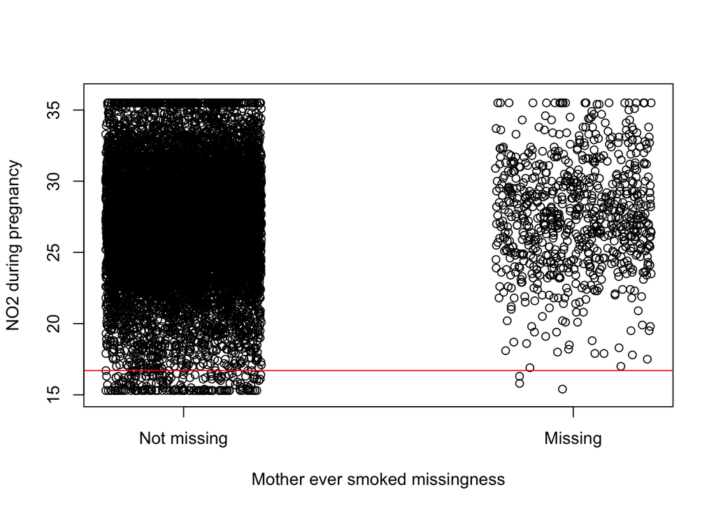

```r
plot(jitter(as.numeric(missing_b650)),alspac_use$no2_preg,ylim=c(15,36),
            xaxt="n",
            xlab="Mother ever smoked missingness",
            ylab="NO2 during pregnancy")
axis(1, at=c(0,1), labels=c("Not missing","Missing"))

abline(h=quantile(alspac_use$no2_preg,1/4,na.rm=T)-1.5*IQR(alspac_use$no2_preg,na.rm=T),col="red")
```

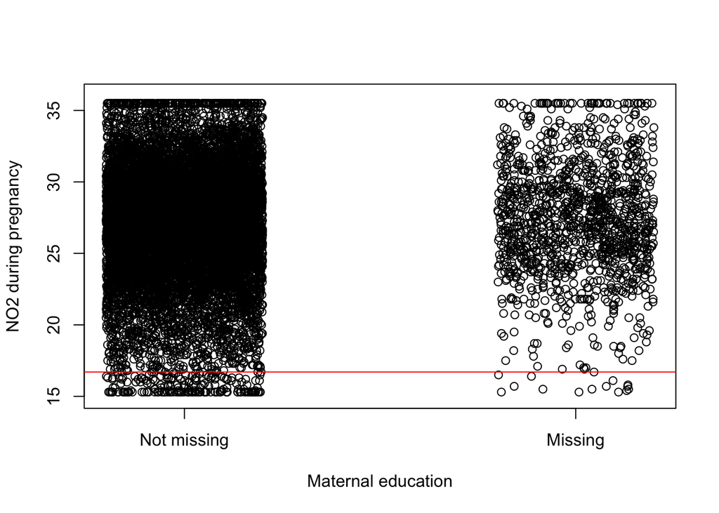

```r
plot(jitter(as.numeric(missing_c645a)),alspac_use$no2_preg,ylim=c(15,36),
            xaxt="n",
            xlab="Maternal education",
            ylab="NO2 during pregnancy")
axis(1, at=c(0,1), labels=c("Not missing","Missing"))

abline(h=quantile(alspac_use$no2_preg,1/4,na.rm=T)-1.5*IQR(alspac_use$no2_preg,na.rm=T),col="red")
```

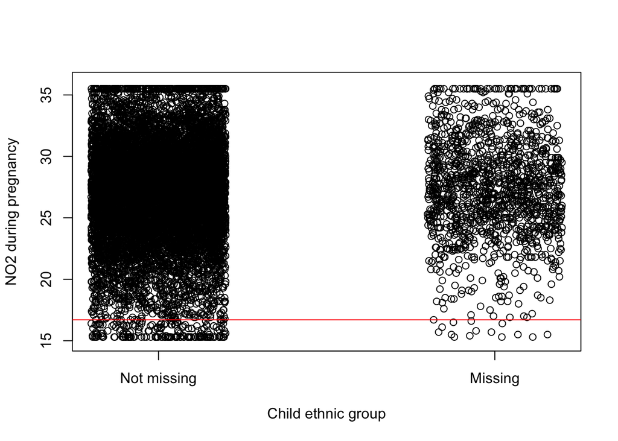

```r
plot(jitter(as.numeric(missing_c800)),alspac_use$no2_preg,ylim=c(15,36),
            xaxt="n",
            xlab="Child ethnic group",
            ylab="NO2 during pregnancy")
axis(1, at=c(0,1), labels=c("Not missing","Missing"))

abline(h=quantile(alspac_use$no2_preg,1/4,na.rm=T)-1.5*IQR(alspac_use$no2_preg,na.rm=T),col="red")
```

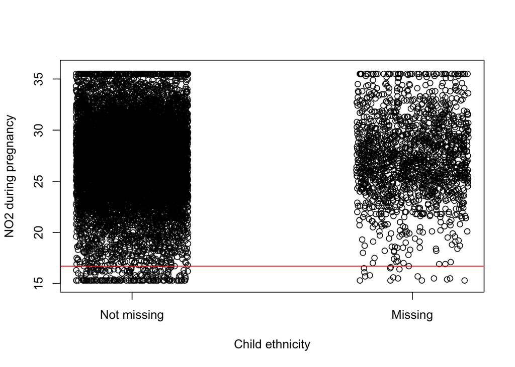

```r
plot(jitter(as.numeric(missing_c804)),alspac_use$no2_preg,ylim=c(15,36),
            xaxt="n",
            xlab="Child ethnicity",
            ylab="NO2 during pregnancy")
axis(1, at=c(0,1), labels=c("Not missing","Missing"))

abline(h=quantile(alspac_use$no2_preg,1/4,na.rm=T)-1.5*IQR(alspac_use$no2_preg,na.rm=T),col="red")
```

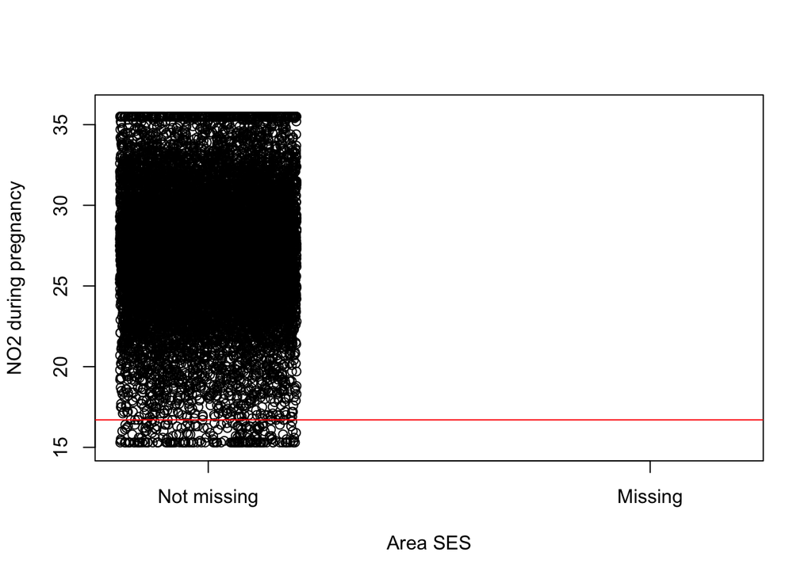

```r
plot(jitter(as.numeric(missing_areases)),alspac_use$no2_preg,ylim=c(15,36),
            xaxt="n",
            xlab="Area SES",
            ylab="NO2 during pregnancy")
axis(1, at=c(0,1), labels=c("Not missing","Missing"))

abline(h=quantile(alspac_use$no2_preg,1/4,na.rm=T)-1.5*IQR(alspac_use$no2_preg,na.rm=T),col="red")
```

Checking if the exposures are different by gender

```r
t.test(alspac_use_no_extra_factor$no2_preg ~ alspac_use_no_extra_factor$kz021)
```

```
##
##  Welch Two Sample t-test
##
## data:  alspac_use_no_extra_factor$no2_preg by alspac_use_no_extra_factor$kz021
## t = 0.70609, df = 11880, p-value = 0.4801
## alternative hypothesis: true difference in means between group Male and group Female is not equal to 0
## 95 percent confidence interval:
##  -0.0941551  0.2001807
## sample estimates:
##   mean in group Male mean in group Female
##             27.01492             26.96191
```

```r
t.test(alspac_use_no_extra_factor$pm25_preg ~ alspac_use_no_extra_factor$kz021)
```

```
##
##  Welch Two Sample t-test
##
## data:  alspac_use_no_extra_factor$pm25_preg by alspac_use_no_extra_factor$kz021
## t = 1.0134, df = 11852, p-value = 0.3109
## alternative hypothesis: true difference in means between group Male and group Female is not equal to 0
## 95 percent confidence interval:
##  -0.01470921  0.04619499
## sample estimates:
##   mean in group Male mean in group Female
##             13.34865             13.33290
```

```r
t.test(alspac_use_no_extra_factor$pm10_preg ~ alspac_use_no_extra_factor$kz021)
```

```
##
##  Welch Two Sample t-test
##
## data:  alspac_use_no_extra_factor$pm10_preg by alspac_use_no_extra_factor$kz021
## t = 0.30433, df = 12153, p-value = 0.7609
## alternative hypothesis: true difference in means between group Male and group Female is not equal to 0
## 95 percent confidence interval:
##  -0.06118993  0.08368208
## sample estimates:
##   mean in group Male mean in group Female
##             31.16920             31.15795
```